# Ford Go Bike Dataset Exploration

## Introduction

> I am going to look at a dataset titled '201902_fordgobike_tripdata.csv' with 183412 rows and 16 columns this dataset has interesting columns such as start and end station of each trip, bike id, and type of user (customer and subscriber).

## Preliminary Wrangling

```python
# import all packages and set plots to be embedded inline
import numpy as np
import pandas as pd
import matplotlib.pyplot as plt
import matplotlib as mpl
import matplotlib.ticker as ticker
import seaborn as sb
import warnings
warnings.simplefilter("ignore")

%matplotlib inline
```

> Load in your dataset and describe its properties through the questions below. Try and motivate your exploration goals through this section.

```python
go_bikes = pd.read_csv('201902_fordgobike_tripdata.csv')
```

## Change start_time and end_time data types to date time.

```python
go_bikes.info()
```

```
<class 'pandas.core.frame.DataFrame'>
RangeIndex: 183412 entries, 0 to 183411
Data columns (total 16 columns):
 #   Column                   Non-Null Count   Dtype
---  ------                   --------------   -----
 0   duration_sec             183412 non-null  int64
 1   start_time               183412 non-null  object
 2   end_time                 183412 non-null  object
 3   start_station_id         183215 non-null  float64
 4   start_station_name       183215 non-null  object
 5   start_station_latitude   183412 non-null  float64
 6   start_station_longitude  183412 non-null  float64
 7   end_station_id           183215 non-null  float64
 8   end_station_name         183215 non-null  object
 9   end_station_latitude     183412 non-null  float64
 10  end_station_longitude    183412 non-null  float64
 11  bike_id                  183412 non-null  int64
 12  user_type                183412 non-null  object
 13  member_birth_year        175147 non-null  float64
 14  member_gender            175147 non-null  object
 15  bike_share_for_all_trip  183412 non-null  object
dtypes: float64(7), int64(2), object(7)
memory usage: 22.4+ MB
```

```python
go_bikes.describe()
```

|  | duration_sec | start_station_id | start_station_latitude | start_station_longitude | end_station_id | end_station_latitude | end_station_longitude | bike_id | member_birth_year |
| --- | --- | --- | --- | --- | --- | --- | --- | --- | --- |
| count | 183412.000000 | 183215.000000 | 183412.000000 | 183412.000000 | 183215.000000 | 183412.000000 | 183412.000000 | 183412.000000 | 175147.000000 |
| mean | 726.078435 | 138.590427 | 37.771223 | -122.352664 | 136.249123 | 37.771427 | -122.352250 | 4472.906375 | 1984.806437 |
| std | 1794.389780 | 111.778864 | 0.099581 | 0.117097 | 111.515131 | 0.099490 | 0.116673 | 1664.383394 | 10.116689 |
| min | 61.000000 | 3.000000 | 37.317298 | -122.453704 | 3.000000 | 37.317298 | -122.453704 | 11.000000 | 1878.000000 |
| 25% | 325.000000 | 47.000000 | 37.770083 | -122.412408 | 44.000000 | 37.770407 | -122.411726 | 3777.000000 | 1980.000000 |
| 50% | 514.000000 | 104.000000 | 37.780760 | -122.398285 | 100.000000 | 37.781010 | -122.398279 | 4958.000000 | 1987.000000 |
| 75% | 796.000000 | 239.000000 | 37.797280 | -122.286533 | 235.000000 | 37.797320 | -122.288045 | 5502.000000 | 1992.000000 |
| max | 85444.000000 | 398.000000 | 37.880222 | -121.874119 | 398.000000 | 37.880222 | -121.874119 | 6645.000000 | 2001.000000 |

```python
go_bikes.shape
```

```
(183412, 16)
```

```python
go_bikes.head()
```

|  | duration_sec | start_time | end_time | start_station_id | start_station_name | start_station_latitude | start_station_longitude | end_station_id | end_station_name | end_station_latitude | end_station_longitude | bike_id | user_type | member_birth_year | member_gender | bike_share_for_all_trip |
| --- | --- | --- | --- | --- | --- | --- | --- | --- | --- | --- | --- | --- | --- | --- | --- | --- |
| 0 | 52185 | 2019-02-28 17:32:10.1450 | 2019-03-01 08:01:55.9750 | 21.0 | Montgomery St BART Station (Market St at 2nd St) | 37.789625 | -122.400811 | 13.0 | Commercial St at Montgomery St | 37.794231 | -122.402923 | 4902 | Customer | 1984.0 | Male | No |
| 1 | 42521 | 2019-02-28 18:53:21.7890 | 2019-03-01 06:42:03.0560 | 23.0 | The Embarcadero at Steuart St | 37.791464 | -122.391034 | 81.0 | Berry St at 4th St | 37.775880 | -122.393170 | 2535 | Customer | NaN | NaN | No |
| 2 | 61854 | 2019-02-28 12:13:13.2180 | 2019-03-01 05:24:08.1460 | 86.0 | Market St at Dolores St | 37.769305 | -122.426826 | 3.0 | Powell St BART Station (Market St at 4th St) | 37.786375 | -122.404904 | 5905 | Customer | 1972.0 | Male | No |
| 3 | 36490 | 2019-02-28 17:54:26.0100 | 2019-03-01 04:02:36.8420 | 375.0 | Grove St at Masonic Ave | 37.774836 | -122.446546 | 70.0 | Central Ave at Fell St | 37.773311 | -122.444293 | 6638 | Subscriber | 1989.0 | Other | No |
| 4 | 1585 | 2019-02-28 23:54:18.5490 | 2019-03-01 00:20:44.0740 | 7.0 | Frank H Ogawa Plaza | 37.804562 | -122.271738 | 222.0 | 10th Ave at E 15th St | 37.792714 | -122.248780 | 4898 | Subscriber | 1974.0 | Male | Yes |

#### Will do bit of cleaning up.

```python
#Change start_time and end_time data types to datetime

#cols = ['start_time','end_time']
#go_bikes[cols] = pd.to_datetime(go_bikes[cols])

go_bikes['start_time'] = pd.to_datetime(go_bikes['start_time'])
go_bikes['end_time'] = pd.to_datetime(go_bikes['end_time'])
```

### Work on solving this issue

```python
#change member birth year to interger instead of float
#df['A'] = df['A'].astype('Int64')

#first we fill the NaN values with 0 rather than dropping the rows.
go_bikes['member_birth_year'] = go_bikes['member_birth_year'].fillna(0)
go_bikes['start_station_id'] = go_bikes['start_station_id'].fillna(0)
go_bikes['end_station_id'] = go_bikes['end_station_id'].fillna(0)

#then we can convert the data type to interger.
go_bikes = go_bikes.astype({'member_birth_year':'int', 'start_station_id':'int', 'end_station_id':'int' })
```

```python
#check data types again
go_bikes.info()
```

```
<class 'pandas.core.frame.DataFrame'>
RangeIndex: 183412 entries, 0 to 183411
Data columns (total 16 columns):
 #   Column                   Non-Null Count   Dtype
---  ------                   --------------   -----
 0   duration_sec             183412 non-null  int64
 1   start_time               183412 non-null  datetime64[ns]
 2   end_time                 183412 non-null  datetime64[ns]
 3   start_station_id         183412 non-null  int32
 4   start_station_name       183215 non-null  object
 5   start_station_latitude   183412 non-null  float64
 6   start_station_longitude  183412 non-null  float64
 7   end_station_id           183412 non-null  int32
 8   end_station_name         183215 non-null  object
 9   end_station_latitude     183412 non-null  float64
 10  end_station_longitude    183412 non-null  float64
 11  bike_id                  183412 non-null  int64
 12  user_type                183412 non-null  object
 13  member_birth_year        183412 non-null  int32
 14  member_gender            175147 non-null  object
 15  bike_share_for_all_trip  183412 non-null  object
dtypes: datetime64[ns](2), float64(4), int32(3), int64(2), object(5)
memory usage: 20.3+ MB
```

```python
go_bikes.head()
```

|  | duration_sec | start_time | end_time | start_station_id | start_station_name | start_station_latitude | start_station_longitude | end_station_id | end_station_name | end_station_latitude | end_station_longitude | bike_id | user_type | member_birth_year | member_gender | bike_share_for_all_trip |
| --- | --- | --- | --- | --- | --- | --- | --- | --- | --- | --- | --- | --- | --- | --- | --- | --- |
| 0 | 52185 | 2019-02-28 17:32:10.145 | 2019-03-01 08:01:55.975 | 21 | Montgomery St BART Station (Market St at 2nd St) | 37.789625 | -122.400811 | 13 | Commercial St at Montgomery St | 37.794231 | -122.402923 | 4902 | Customer | 1984 | Male | No |
| 1 | 42521 | 2019-02-28 18:53:21.789 | 2019-03-01 06:42:03.056 | 23 | The Embarcadero at Steuart St | 37.791464 | -122.391034 | 81 | Berry St at 4th St | 37.775880 | -122.393170 | 2535 | Customer | 0 | NaN | No |
| 2 | 61854 | 2019-02-28 12:13:13.218 | 2019-03-01 05:24:08.146 | 86 | Market St at Dolores St | 37.769305 | -122.426826 | 3 | Powell St BART Station (Market St at 4th St) | 37.786375 | -122.404904 | 5905 | Customer | 1972 | Male | No |
| 3 | 36490 | 2019-02-28 17:54:26.010 | 2019-03-01 04:02:36.842 | 375 | Grove St at Masonic Ave | 37.774836 | -122.446546 | 70 | Central Ave at Fell St | 37.773311 | -122.444293 | 6638 | Subscriber | 1989 | Other | No |
| 4 | 1585 | 2019-02-28 23:54:18.549 | 2019-03-01 00:20:44.074 | 7 | Frank H Ogawa Plaza | 37.804562 | -122.271738 | 222 | 10th Ave at E 15th St | 37.792714 | -122.248780 | 4898 | Subscriber | 1974 | Male | Yes |

```python
#noticing that "bike_id is not the first column and so we will rearrange some columns"

def reorder_columns(columns, first_cols=['bike_id','start_time','end_time','duration_sec']):
    columns = list(set(columns) - set(first_cols))
    new_order = first_cols + columns
    return new_order
```

```python
reorder_columns(go_bikes, first_cols=['bike_id','start_time','end_time','duration_sec'])
```

```
['bike_id',
 'start_time',
 'end_time',
 'duration_sec',
 'start_station_id',
 'end_station_longitude',
 'member_gender',
 'user_type',
 'bike_share_for_all_trip',
 'start_station_name',
 'end_station_id',
 'end_station_latitude',
 'start_station_latitude',
 'end_station_name',
 'start_station_longitude',
 'member_birth_year']
```

```python
#now we assign the columns to our dataframe.

reordered_cols = reorder_columns(go_bikes, first_cols=['bike_id','start_time','end_time','duration_sec'])
go_bikes = go_bikes[reordered_cols]
```

```python
go_bikes.head(2)
```

|  | bike_id | start_time | end_time | duration_sec | start_station_id | end_station_longitude | member_gender | user_type | bike_share_for_all_trip | start_station_name | end_station_id | end_station_latitude | start_station_latitude | end_station_name | start_station_longitude | member_birth_year |
| --- | --- | --- | --- | --- | --- | --- | --- | --- | --- | --- | --- | --- | --- | --- | --- | --- |
| 0 | 4902 | 2019-02-28 17:32:10.145 | 2019-03-01 08:01:55.975 | 52185 | 21 | -122.402923 | Male | Customer | No | Montgomery St BART Station (Market St at 2nd St) | 13 | 37.794231 | 37.789625 | Commercial St at Montgomery St | -122.400811 | 1984 |
| 1 | 2535 | 2019-02-28 18:53:21.789 | 2019-03-01 06:42:03.056 | 42521 | 23 | -122.393170 | NaN | Customer | No | The Embarcadero at Steuart St | 81 | 37.775880 | 37.791464 | Berry St at 4th St | -122.391034 | 0 |

```python
#look for null values.

go_bikes.isna().sum()
```

```
bike_id                       0
start_time                    0
end_time                      0
duration_sec                  0
start_station_id              0
end_station_longitude         0
member_gender              8265
user_type                     0
bike_share_for_all_trip       0
start_station_name          197
end_station_id                0
end_station_latitude          0
start_station_latitude        0
end_station_name            197
start_station_longitude       0
member_birth_year             0
dtype: int64
```

### Dataset structure

> The dataset has **183412 rows** and **16 features** namely ('bike_id','start_time','end_time','duration_sec','start_station_id', 'end_station_id','start_station_name','end_station_longitude','end_station_name','bike_share_for_all_trip','member_birth_year', 'start_station_longitude','member_gender','user_type','start_station_latitude','end_station_latitude')

### Main features of interest

> I am interested to see where the bike activity occurs the most. I would like to know the distribution of gender among the bike users.

## Univariate Exploration

```python
#I want to see if there are duplicates in the dataset under the bike_id column.

go_bikes['bike_id'].value_counts().sort_values(ascending=True)
```

```
5891      1
350       1
2643      1
2637      1
3585      1
       ...
5175    173
4422    174
5014    174
4814    176
4794    191
Name: bike_id, Length: 4646, dtype: int64
```

```python
go_bikes.bike_id.duplicated().value_counts()
```

```
True     178766
False      4646
Name: bike_id, dtype: int64
```

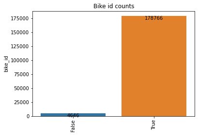

```python
#To visualize the data

repeated = go_bikes.bike_id.duplicated().value_counts()

sb.barplot(repeated.index.values, repeated)

plt.xticks(rotation=90)

#print values on each bar
for i in range (repeated.shape[0]):
    count = repeated[i]

    plt.text(i, count+300, count, ha = 'center', va='top')

plt.title('Bike id counts');
```

## Observation

> We see a significant amount of bike_ids that appear multiple times on this dataset.

## We see 178766 duplicates on the bike id column and 4646 unique bike ids, what could be the reason for this?

```python
#Checking information of duplicated bike id, Check to see if the duplicate is only on the bike_id column or the entire feature set.

go_bikes.loc[go_bikes['bike_id'] == 5175]
```

|  | bike_id | start_time | end_time | duration_sec | start_station_id | end_station_longitude | member_gender | user_type | bike_share_for_all_trip | start_station_name | end_station_id | end_station_latitude | start_station_latitude | end_station_name | start_station_longitude | member_birth_year |
| --- | --- | --- | --- | --- | --- | --- | --- | --- | --- | --- | --- | --- | --- | --- | --- | --- |
| 2108 | 5175 | 2019-02-28 18:07:48.861 | 2019-02-28 18:31:37.701 | 1428 | 363 | -122.422140 | Female | Subscriber | No | Salesforce Transit Center (Natoma St at 2nd St) | 142 | 37.745739 | 37.787492 | Guerrero Park | -122.398285 | 1989 |
| 8474 | 5175 | 2019-02-28 08:16:34.317 | 2019-02-28 08:28:23.373 | 709 | 383 | -122.398285 | Female | Subscriber | No | Golden Gate Ave at Franklin St | 363 | 37.787492 | 37.780787 | Salesforce Transit Center (Natoma St at 2nd St) | -122.421934 | 1962 |
| 9472 | 5175 | 2019-02-28 06:57:35.291 | 2019-02-28 07:12:26.379 | 891 | 22 | -122.421934 | Female | Subscriber | No | Howard St at Beale St | 383 | 37.780787 | 37.789756 | Golden Gate Ave at Franklin St | -122.394643 | 1977 |
| 10306 | 5175 | 2019-02-27 20:53:28.896 | 2019-02-27 21:00:53.572 | 444 | 9 | -122.394643 | Male | Subscriber | No | Broadway at Battery St | 22 | 37.789756 | 37.798572 | Howard St at Beale St | -122.400869 | 1992 |
| 10371 | 5175 | 2019-02-27 20:45:25.999 | 2019-02-27 20:48:14.077 | 168 | 6 | -122.400869 | Male | Subscriber | No | The Embarcadero at Sansome St | 9 | 37.798572 | 37.804770 | Broadway at Battery St | -122.403234 | 1986 |
| ... | ... | ... | ... | ... | ... | ... | ... | ... | ... | ... | ... | ... | ... | ... | ... | ... |
| 182288 | 5175 | 2019-02-01 08:25:48.816 | 2019-02-01 08:33:45.060 | 476 | 44 | -122.402923 | Male | Subscriber | Yes | Civic Center/UN Plaza BART Station (Market St ... | 13 | 37.794231 | 37.781074 | Commercial St at Montgomery St | -122.411738 | 1976 |
| 182453 | 5175 | 2019-02-01 08:13:15.479 | 2019-02-01 08:22:52.922 | 577 | 26 | -122.411738 | NaN | Subscriber | No | 1st St at Folsom St | 44 | 37.781074 | 37.787290 | Civic Center/UN Plaza BART Station (Market St ... | -122.394380 | 0 |
| 182911 | 5175 | 2019-02-01 07:36:29.592 | 2019-02-01 07:42:25.935 | 356 | 81 | -122.394380 | Male | Subscriber | No | Berry St at 4th St | 26 | 37.787290 | 37.775880 | 1st St at Folsom St | -122.393170 | 1991 |
| 182988 | 5175 | 2019-02-01 07:13:40.159 | 2019-02-01 07:32:21.934 | 1121 | 132 | -122.393170 | Female | Subscriber | No | 24th St at Chattanooga St | 81 | 37.775880 | 37.751819 | Berry St at 4th St | -122.426614 | 1980 |
| 183271 | 5175 | 2019-02-01 05:40:53.003 | 2019-02-01 06:02:41.923 | 1308 | 323 | -122.426614 | Male | Subscriber | Yes | Broadway at Kearny | 132 | 37.751819 | 37.798014 | 24th St at Chattanooga St | -122.405950 | 1973 |

173 rows × 16 columns

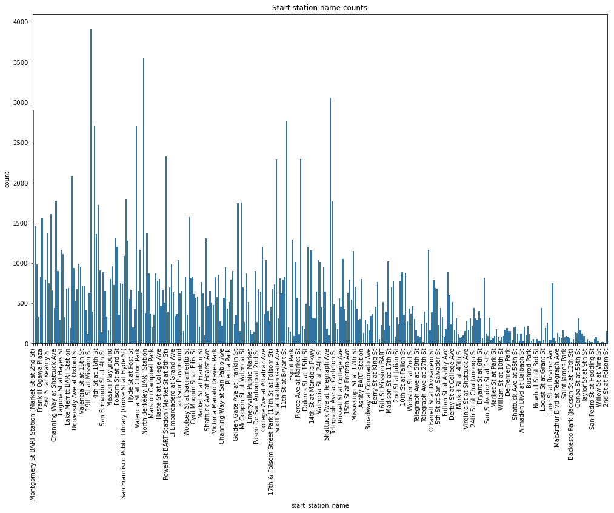

```python
#Display start_station_name vs value count

fig, ax = plt.subplots(figsize = [17,10])
plt.xticks(rotation=90)
default_color = sb.color_palette()[0]
sb.countplot(data = go_bikes, x = 'start_station_name', color = default_color)

#control the number of values that appear on the x axis
every_nth = 4
for n, label in enumerate(ax.xaxis.get_ticklabels()):
    if n % every_nth != 0:
        label.set_visible(False)


plt.title('Start station name counts')
plt.show()
```

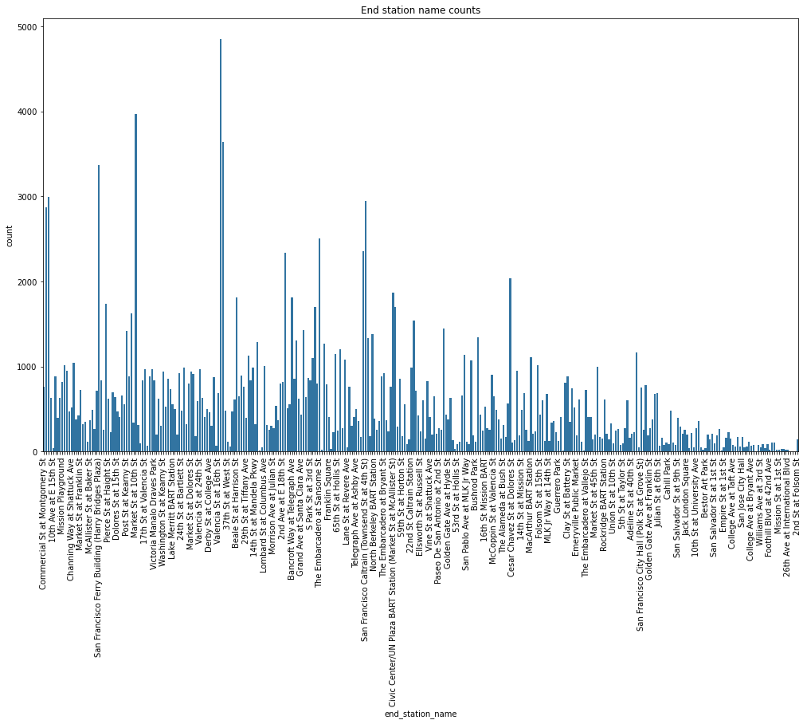

```python
#Display end_station_name vs value count

fig, ax = plt.subplots(figsize = [17,10])
plt.xticks(rotation=90)
default_color = sb.color_palette()[0]
sb.countplot(data = go_bikes, x = 'end_station_name', color = default_color)

#control the number of values that appear on the x axis
every_nth = 4
for n, label in enumerate(ax.xaxis.get_ticklabels()):
    if n % every_nth != 0:
        label.set_visible(False)


plt.title('End station name counts')
plt.show()
```

```python
#Display gender distribution
#first we need to get data from the 'member_gender' column
pie_data = go_bikes.member_gender.value_counts()
pie_data
```

```
Male      130651
Female     40844
Other       3652
Name: member_gender, dtype: int64
```

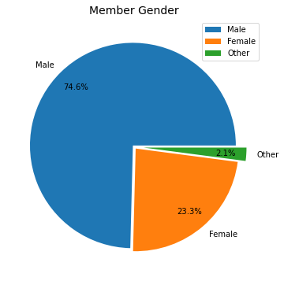

```python
#Plot the pie chart

pie, ax = plt.subplots(figsize=[10,6])
labels = pie_data.keys()
explode = (0.02,0.02,0.09)
plt.pie(x = pie_data, autopct = "%.1f%%", explode = explode, labels = labels, pctdistance = 0.8)
plt.title("Member Gender", fontsize = 14);
plt.legend(["Male", "Female", "Other"]);
```

```python
#Display user type distribution

user_type_data = go_bikes.user_type.value_counts()
user_type_data
```

```
Subscriber    163544
Customer       19868
Name: user_type, dtype: int64
```

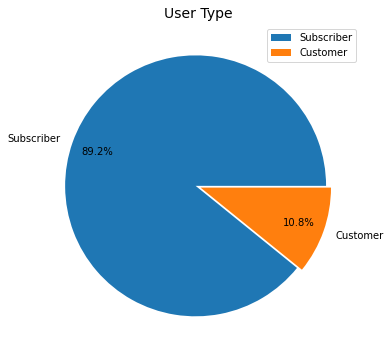

```python
#Plot user type pie chart

pie, ax = plt.subplots(figsize=[10,6])
labels = user_type_data.keys()
explode = (0.02,0.02)
plt.pie(x = user_type_data, autopct = "%.1f%%", explode = explode, labels = labels, pctdistance = 0.8)
plt.title("User Type", fontsize = 14);
plt.legend(["Subscriber", "Customer"]);
```

```python
#Display duration spent renting out bikes in a histogram

duration_data = go_bikes.duration_sec.value_counts()
duration_data
```

```
272      311
324      292
323      291
306      291
305      290
        ...
5803       1
11870      1
5931       1
15964      1
5058       1
Name: duration_sec, Length: 4752, dtype: int64
```

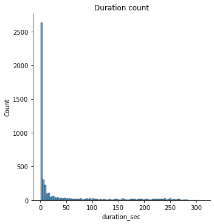

```python
#plot histogram
sb.displot(x= duration_data, kde=False)
plt.title('Duration count')
plt.show()
```

> How many null values are in the dataset and in which columns are these null values in?

```python
#look for null values.

go_bikes.isna().sum()
```

```
bike_id                       0
start_time                    0
end_time                      0
duration_sec                  0
start_station_id              0
end_station_longitude         0
member_gender              8265
user_type                     0
bike_share_for_all_trip       0
start_station_name          197
end_station_id                0
end_station_latitude          0
start_station_latitude        0
end_station_name            197
start_station_longitude       0
member_birth_year             0
dtype: int64
```

```python
# we will drop the columns that do not have null values and keey the ones with null values only.
null_values = go_bikes.drop(['bike_id', 'start_time', 'end_time','duration_sec','end_station_latitude','end_station_longitude','user_type',\
                            'start_station_longitude','start_station_latitude','bike_share_for_all_trip','start_station_id','end_station_id',\
                            'member_birth_year'], axis=1).isna().sum()
```

```python
null_values
```

```
member_gender         8265
start_station_name     197
end_station_name       197
dtype: int64
```

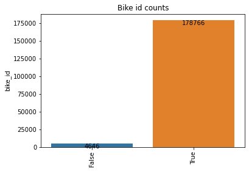

```python
#To visualize the data

repeated = go_bikes.bike_id.duplicated().value_counts()

sb.barplot(repeated.index.values, repeated)

plt.xticks(rotation=90)

#print values on each bar
for i in range (repeated.shape[0]):
    count = repeated[i]

    plt.text(i, count+300, count, ha = 'center', va='top')


plt.title('Bike id counts');
```

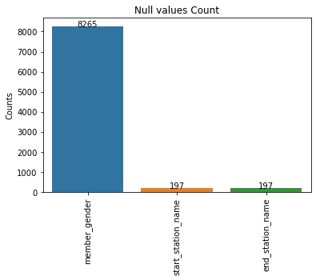

```python
sb.barplot(null_values.index.values, null_values)

plt.xticks(rotation=90)

#print values on each bar
for i in range (null_values.shape[0]):
    count = null_values[i]

    plt.text(i, count+300, count, ha = 'center', va='top')

plt.ylabel("Counts")
plt.title("Null values Count");
```

### Discuss the distribution(s) of your variable(s) of interest. Were there any unusual points? Did you need to perform any transformations?

> There are bike ids that are repeated a significant amount of times

### Of the features you investigated, were there any unusual distributions? Did you perform any operations on the data to tidy, adjust, or change the form of the data? If so, why did you do this?

> There are some interesting distributions such as certain start stations have significantly higher counts than others, the distribution between subscriber and customer has 89.2% of users as subscribers.

## Bivariate Exploration

```python
#select only values that are not zero
birth_year = go_bikes[go_bikes['member_birth_year'] !=0]
birth_years = birth_year[['member_birth_year','duration_sec']]
```

```python
birth_years
```

|  | member_birth_year | duration_sec |
| --- | --- | --- |
| 0 | 1984 | 52185 |
| 2 | 1972 | 61854 |
| 3 | 1989 | 36490 |
| 4 | 1974 | 1585 |
| 5 | 1959 | 1793 |
| ... | ... | ... |
| 183407 | 1996 | 480 |
| 183408 | 1984 | 313 |
| 183409 | 1990 | 141 |
| 183410 | 1988 | 139 |
| 183411 | 1989 | 271 |

175147 rows × 2 columns

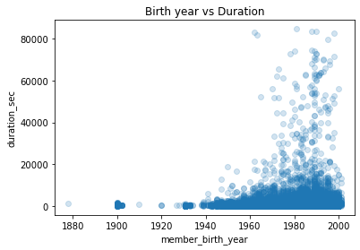

```python
plt.scatter(data = birth_years, x = 'member_birth_year', y = 'duration_sec', alpha=1/5)
plt.xlabel('member_birth_year')
plt.ylabel('duration_sec')
plt.title("Birth year vs Duration");
```

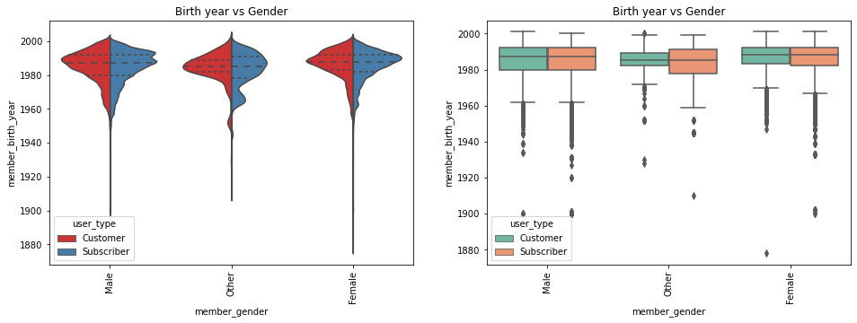

```python
plt.figure(figsize = [16, 5])
base_color = sb.color_palette()[0]

#Left plot, violin plot
plt.subplot(1, 2, 1)
sb.violinplot(data = birth_year, x = 'member_gender', y = 'member_birth_year',palette = 'Set1', inner = 'quartile', split = True, hue = 'user_type')
plt.xticks(rotation=90)
plt.xlabel('member_gender')
plt.ylabel('member_birth_year')
plt.title("Birth year vs Gender")

# RIGHT plot: box plot
plt.subplot(1, 2, 2)
sb.boxplot(data = birth_year, x = 'member_gender', y = 'member_birth_year', palette = 'Set2', hue = 'user_type')
plt.xticks(rotation=90)
plt.title("Birth year vs Gender");
```

### Relationships observed.

> In the duration vs birth year plot, members that are younger spend more time per trip.

## Multivariate Exploration

```python
#a single bike id vs multiple start stations

one_bike = go_bikes[go_bikes['bike_id'] == 5175]
one_bike
```

|  | bike_id | start_time | end_time | duration_sec | start_station_id | end_station_longitude | member_gender | user_type | bike_share_for_all_trip | start_station_name | end_station_id | end_station_latitude | start_station_latitude | end_station_name | start_station_longitude | member_birth_year |
| --- | --- | --- | --- | --- | --- | --- | --- | --- | --- | --- | --- | --- | --- | --- | --- | --- |
| 2108 | 5175 | 2019-02-28 18:07:48.861 | 2019-02-28 18:31:37.701 | 1428 | 363 | -122.422140 | Female | Subscriber | No | Salesforce Transit Center (Natoma St at 2nd St) | 142 | 37.745739 | 37.787492 | Guerrero Park | -122.398285 | 1989 |
| 8474 | 5175 | 2019-02-28 08:16:34.317 | 2019-02-28 08:28:23.373 | 709 | 383 | -122.398285 | Female | Subscriber | No | Golden Gate Ave at Franklin St | 363 | 37.787492 | 37.780787 | Salesforce Transit Center (Natoma St at 2nd St) | -122.421934 | 1962 |
| 9472 | 5175 | 2019-02-28 06:57:35.291 | 2019-02-28 07:12:26.379 | 891 | 22 | -122.421934 | Female | Subscriber | No | Howard St at Beale St | 383 | 37.780787 | 37.789756 | Golden Gate Ave at Franklin St | -122.394643 | 1977 |
| 10306 | 5175 | 2019-02-27 20:53:28.896 | 2019-02-27 21:00:53.572 | 444 | 9 | -122.394643 | Male | Subscriber | No | Broadway at Battery St | 22 | 37.789756 | 37.798572 | Howard St at Beale St | -122.400869 | 1992 |
| 10371 | 5175 | 2019-02-27 20:45:25.999 | 2019-02-27 20:48:14.077 | 168 | 6 | -122.400869 | Male | Subscriber | No | The Embarcadero at Sansome St | 9 | 37.798572 | 37.804770 | Broadway at Battery St | -122.403234 | 1986 |
| ... | ... | ... | ... | ... | ... | ... | ... | ... | ... | ... | ... | ... | ... | ... | ... | ... |
| 182288 | 5175 | 2019-02-01 08:25:48.816 | 2019-02-01 08:33:45.060 | 476 | 44 | -122.402923 | Male | Subscriber | Yes | Civic Center/UN Plaza BART Station (Market St ... | 13 | 37.794231 | 37.781074 | Commercial St at Montgomery St | -122.411738 | 1976 |
| 182453 | 5175 | 2019-02-01 08:13:15.479 | 2019-02-01 08:22:52.922 | 577 | 26 | -122.411738 | NaN | Subscriber | No | 1st St at Folsom St | 44 | 37.781074 | 37.787290 | Civic Center/UN Plaza BART Station (Market St ... | -122.394380 | 0 |
| 182911 | 5175 | 2019-02-01 07:36:29.592 | 2019-02-01 07:42:25.935 | 356 | 81 | -122.394380 | Male | Subscriber | No | Berry St at 4th St | 26 | 37.787290 | 37.775880 | 1st St at Folsom St | -122.393170 | 1991 |
| 182988 | 5175 | 2019-02-01 07:13:40.159 | 2019-02-01 07:32:21.934 | 1121 | 132 | -122.393170 | Female | Subscriber | No | 24th St at Chattanooga St | 81 | 37.775880 | 37.751819 | Berry St at 4th St | -122.426614 | 1980 |
| 183271 | 5175 | 2019-02-01 05:40:53.003 | 2019-02-01 06:02:41.923 | 1308 | 323 | -122.426614 | Male | Subscriber | Yes | Broadway at Kearny | 132 | 37.751819 | 37.798014 | 24th St at Chattanooga St | -122.405950 | 1973 |

173 rows × 16 columns

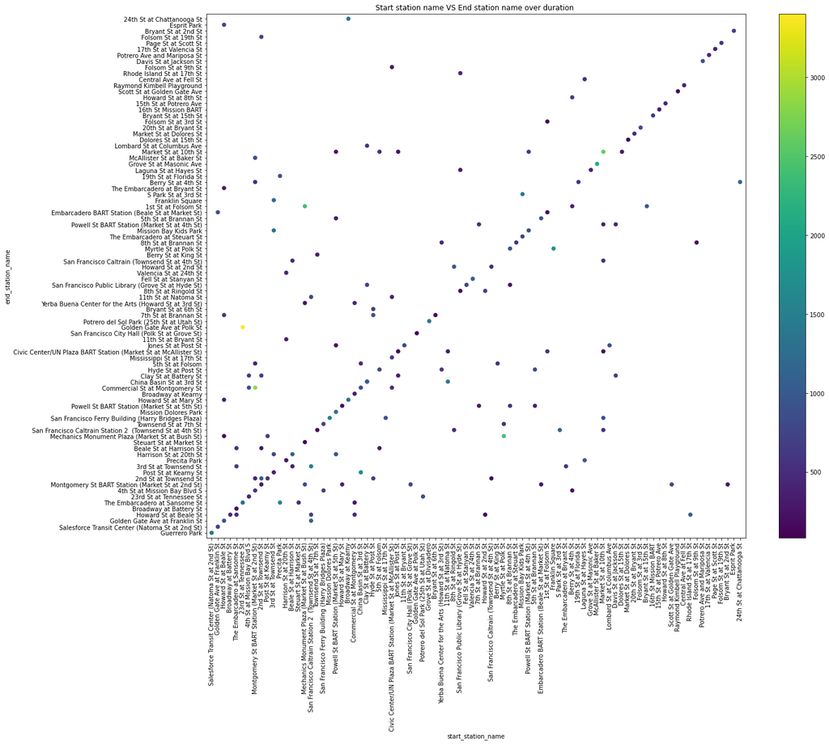

```python
#unique bike id 5175 through start and end stations

plt.figure(figsize = (20,16))
plt.scatter(data = one_bike, x = 'start_station_name', y = 'end_station_name', c = 'duration_sec')
plt.xticks(rotation = 90)
plt.margins(0.01)
plt.xlabel('start_station_name')
plt.ylabel('end_station_name')
plt.title('Start station name VS End station name over duration ')
plt.colorbar();
```

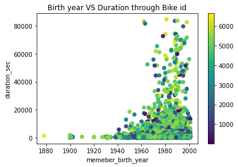

```python
#plot member birth year vs duration in seconds with a colormap of different bike ids

plt.scatter(data = birth_year, x = 'member_birth_year', y = 'duration_sec', c='bike_id')
plt.xlabel('memeber_birth_year')
plt.ylabel('duration_sec')
plt.title('Birth year VS Duration through Bike id')

plt.colorbar();
```

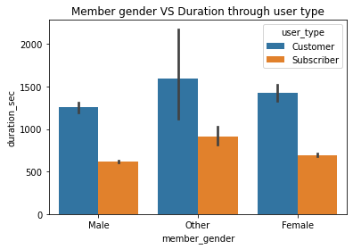

```python
#plotting member gender vs duration grouped by the user type
ax = sb.barplot(data = birth_year, x = 'member_gender', y = 'duration_sec', hue = 'user_type')
plt.title('Member gender VS Duration through user type');
```

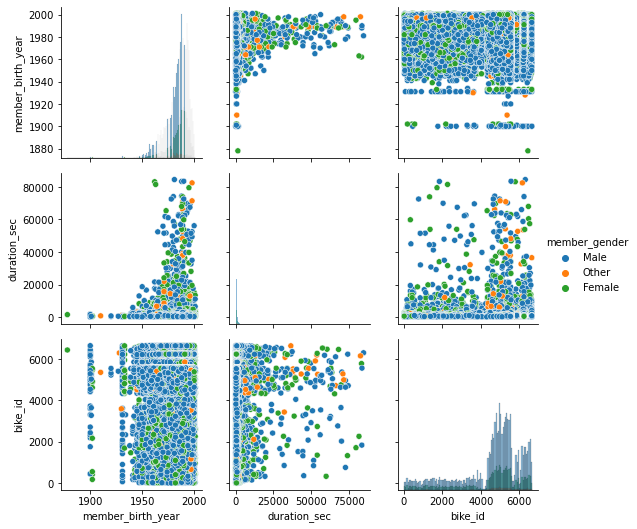

```python
#plotting a pairgrid looking at member birth year, bike id and duration grouped by member gender
grid = sb.PairGrid(data = birth_year, vars = ['member_birth_year', 'duration_sec', 'bike_id'], hue = 'member_gender')
grid.map_diag(sb.histplot)
grid.map_offdiag(sb.scatterplot)
grid.add_legend();
```

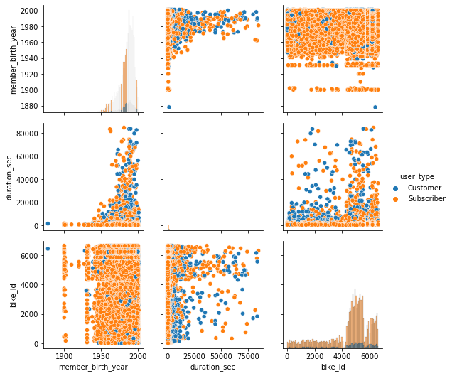

```python
#plotting a pairgrid looking at member birth year, bike id and duration grouped by user type
grid = sb.PairGrid(data = birth_year, vars = ['member_birth_year', 'duration_sec', 'bike_id'], hue = 'user_type')
grid.map_diag(sb.histplot)
grid.map_offdiag(sb.scatterplot)
grid.add_legend();
```

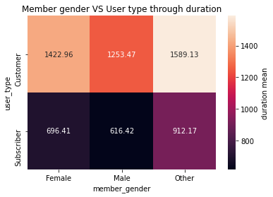

```python
#heatmap looking at average duration of gender member and user type

heat_map= birth_year.groupby(['member_gender', 'user_type']).mean()['duration_sec']
heat_map= heat_map.reset_index(name = 'duration_sec_avg')
heat_map= heat_map.pivot(index = 'user_type', columns = 'member_gender',
                            values = 'duration_sec_avg')
sb.heatmap(heat_map, annot = True, fmt = '.2f',
           cbar_kws = {'label' : 'duration mean'});
plt.title('Member gender VS User type through duration');
```

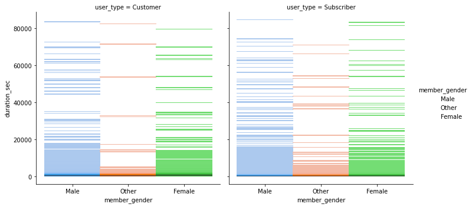

```python
#facetgrid of user type duration spent grouped by member gender
gender_user = sb.FacetGrid(data = birth_year, col = 'user_type', size = 5, hue = 'member_gender')
gender_user.map(sb.histplot, 'member_gender', 'duration_sec')
gender_user.add_legend();
```